# Aside

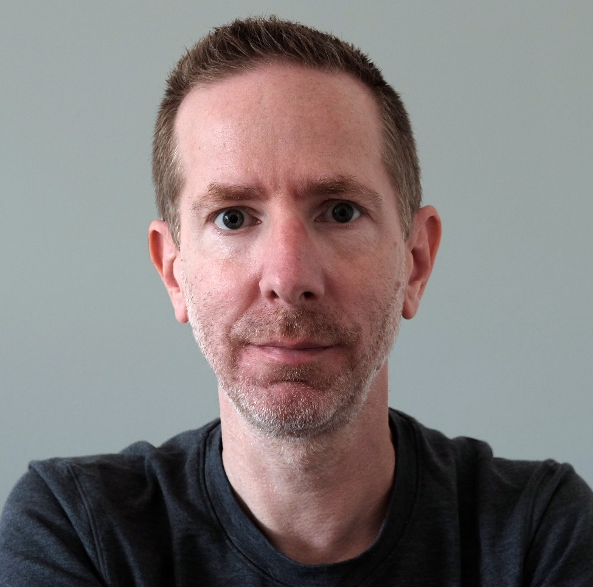

[Download a PDF of this CV](https://ab604.uk/cv/bailey_cv.pdf)

## Contact

- alistair@ab604.uk
- ab604.uk
- 0000-0003-0023-8679
- github.com/ab604
- [@ab604.uk](https://bsky.app/profile/ab604.uk)

## Language Skills

R

Markdown

Bash

Latex

Git

HTML

CSS

Python

JavaScript

SQL

## Disclaimer

Made with the R package [**pagedown**](https://github.com/rstudio/pagedown).

The source code is available [on github.com/ab604/abailey-cv](https://github.com/ab604/abailey-cv).

The fonts are Inter and [Permanent Marker](https://fonts.google.com/specimen/Permanent+Marker)

Last updated on 2025-12-29.

# Main

## Alistair Bailey

An engineer by training, I have since worked primarily as an informatician and research scientist. I am currently a Research Fellow in Microfluidic Hydrogen-Deuterium Exchange at the [University of Southampton.](https://www.soton.ac.uk)

The topic of my research career has been the role of HLA antigen processing and presentation in disease recognition by T cells. In [cancer](https://www.cancerresearchuk.org/funding-for-researchers/accelerator-award/portfolio-funded-projects-outputs) this has focused on HLA-presented [tumour antigens](https://doi.org/10.1111/imm.13578), and in infectious disease the focus has been HLA-presented [viral](https://doi.org/10.1371/journal.ppat.1009894) and bacterial antigens. Exploiting these targets has the potential for enhancing personalised therapies, vaccine development and understanding allergy.

I have contributed to research into [COVID19](https://doi.org/10.1515/cclm-2022-1000), [skin sensitization to chemical allergens](https://doi.org/10.1093/toxsci/kfaa184), [asthma](https://doi.org/10.1111/cea.14197) and [contagious cancer in the Tasmanian Devil](https://doi.org/10.1111/imm.13307).

My core skills are processing and analysing data from whole exome sequencing, RNAseq, scRNAseq and proteomics assays. My workflow combines command line tools with micromamba, the R programming language and git version control.

Proteomics data I have curated, deposited and I am the data controller for is deposited at the [PRoteomics IDEntifications Archive](https://www.ebi.ac.uk/pride/). Whole Exome and RNAseq data I have curated, deposited and I am the data controller for is deposited at the [European Genome-phenome Archive](https://ega-archive.org/).

I am a [Data and Software Carpentry](https://carpentries.org/) instructor and I have also created and delivered my own workshops to teach [foundational R coding and data science skills](https://ab604.github.io/docs/coding-together-2019/) to bioscientists and [web design](https://ab604.github.io/webpage-design/) to librarians.

## Education

### Carpentries Instructor

Worldwide

The Carpentries

2017

- I trained as a [Carpentries](https://carpentries.org/) instructor as part of their volunteer led mission to increase global capacity in essential data and computational skills for conducting efficient, open, and reproducible research.

### Machine Learning

Stanford University

Coursera

2016

- 10 week online introduction to machine learning.

### Data Science Specialization

John Hopkins University

Coursera

2015

- 12 month online set of courses on data science using R, git and command line tools.

### PhD, Immunology

Cancer Sciences, University of Southampton

Southampton, UK

2013 - 2008

- Thesis: Relating the structure, function and dynamics of the MHC Class I antigen presenting molecule.

### BEng, Civil Engineering

University of Southampton

Southampton, UK

2008 - 2005

- First Class Honours in Civil Engineering.

### Engineering, Science & Mathematics Foundation Year

University of Southampton

Southampton, UK

2005 - 2004

- Maths and physics foundation year preparation for undergraduate study.

### BTEC ND Audio-Visual Production

Bournemouth & Poole College of Art & Design

Bournemouth, UK

1994 - 1992

- Foundation course in film, photography, TV and radio production.

## Research Experience

### Research Fellow

Cancer Sciences, University of Southampton

Southampton, UK

2025

- Research Fellow in Microfluidic HDX

### Research Fellow

School of Biological Sciences, University of Southampton

Southampton, UK

2023

- scRNAseq analysis of T-cell response to neutrophil exposure. Bioinformatician maternity leave cover for Medical Research Council funded project.

### Research Fellow

Centre for Proteomic Research/Cancer Sciences,  
University of Southampton

Southampton, UK

2022 - 2018

- Cancer Research UK Accelerator: this project aims to identify potential treatment targets for hard to treat cancers using multi-omics methods. In this project our focus was on oesophageal, lung and neuroendocrine cancers.  
  As an informatician I processed, analysed and managed data from whole exome sequencing, RNAseq, scRNAseq and proteomics.  
  For sequencing fastq data, my workflow comprised of a mixture of command line tools using bash scripts and R/RStudio. I followed the [Broad Institute Best Practices for genomic data analysis](https://gatk.broadinstitute.org/hc/en-us) and [Cornell Bioinformatics Core](https://abc.med.cornell.edu/). For proteomics data, my worklfow used [Peaks Studio](https://www.bioinfor.com/peaks-studio/), and post-process in R and RStudio.  
  Scripts and processed data were managed using git version control. Raw data was deposited along with processed outputs in [PRoteomics IDEntifications Archive](https://www.ebi.ac.uk/pride/) and the [European Phenome-Genome Archive](https://ega-archive.org/).

We also developed our method to identify treatment targets for infectious diseases from influenza and bacterial proteins. In 2020 I also worked to develop a COVID19 test using proteomics methods.

### Research Fellow

Centre for Proteomic Research/Cancer Sciences,  
University of Southampton

Southampton, UK

2018 - 2015

- Developed peptidomics methodology at the UoS for research into the role of MHC molecules in skin sensitisation to chemical allergy.

### Research Fellow

Cancer Sciences, University of Southampton

Southampton, UK

2015 - 2013

- MRC Centenary Fellow

## Teaching & Education Experience

I enjoy teaching foundational coding and data science skills to researchers and developing evidence-based best practices. I am especially interested in helping novices and making coding more accessible to all.

### Learning Technologist

University of Southampton

Southampton, UK

2024 - 2023

- Part-time role supporting Engagement Librarians in the design, development and deployment of webpages and other electronic resources.

### [Webpage Design](https://ab604.github.io/webpage-design/)

University of Southampton

Southampton, UK

2024

- I created a webpage design workshop and materials for Librarians at the University of Southampton

### BIOL 2013: Introduction to bioinformatics

University of Southampton

Southampton, UK

2022 - 2021

- I taught the undegraduate introduction to bioinformatics module on variant discovery using the University Galaxy Server.

### [Coding Together](https://ab604.github.io/docs/coding-together-2019/)

University of Southampton

Southampton, UK

2020 - 2019

- I created and taught an eight week series of collaborative workshops to teach foundational R coding and data science skills based on Carpentries materials.

### Academic Support Tutor

IntoUniversity Millbrook

Southampton, UK

2019 - 2018

- [IntoUniversity](https://intouniversity.org/) supports young people from disadvantaged backgrounds to attain either a university place or another chosen aspiration. I volunteered as an academic support tutor for secondary school learners.

### Software Carpentry

Umeå University

Umeå, Sweden

2018

- Taught R for Reproducible Research and assisted in Command Line Basics.

### [British Society for Proteomics 2018 Data Science Workshop](https://ab604.github.io/docs/bspr_workshop_2018/index.html)

University of Bradford

Bradford, UK

2018

- I created and taught a proteomics data science workshop including introduction to R, Volcano plots, heatmaps and peptide logos.

### Data Carpentry

University of Southampton

Southampton, UK

2017

- Taught R for Reproducible Research and assisted in Command Line Basics and git.

### Data Carpentry

University of Southampton

Southampton, UK

2017

- Taught R for Reproducible Research and assisted in introduction to SQL.

### Software Carpentry

University of Southampton

Southampton, UK

2017

- Assisted with python and git for reproducible research.

## Research Data

### [Immunopeptidomic analysis of influenza A virus infected human tissues identifies internal proteins as a rich source of HLA ligands](https://doi.org/10.1371/journal.ppat.1009894), Publicly released

N/A

N/A

N/A

- Proteomics data: [PRIDE Project PXD022884](https://www.ebi.ac.uk/pride/archive/projects/PXD022884)

### [Identification of neoantigens in esophageal adenocarcinoma](https://doi.org/10.1111/imm.13578), Publicly released

N/A

N/A

N/A

- Proteomics data: [PRIDE Project ID PXD031108](https://www.ebi.ac.uk/pride/archive/projects/PXD031108)
- WES & RNAseq data EGA Study ID EGAS00001005957

### [Characterization of the Class I MHC Peptidome Resulting From DNCB Exposure of HaCaT Cells](https://doi.org/10.1093/toxsci/kfaa184), Publicly released

N/A

N/A

N/A

- Proteomics data: [PRIDE Project PXD021373](https://www.ebi.ac.uk/pride/archive/projects/PXD021373)

### Neoantigen identification in pancreatic neuroendocrine tumours, Unreleased pending publication

N/A

N/A

N/A

- Proteomics data: PRIDE Project ID PXD037449
- WES & RNAseq data EGA Study ID EGAS00001006722

### Immunopeptidomics guided identification of neoantigens in non-small cell lung cancer, Unreleased pending publication

N/A

N/A

N/A

- Proteomics data: PRIDE Project ID PXD028990
- WES & RNAseq data EGA Study ID EGAS00001005499

### Immunopeptidomics of a brain tumour cell line to identify HLA presented Zika, Unreleased pending publication

N/A

N/A

N/A

- Proteomics data: PRIDE Project ID PXD037627

### Non-small cell lung cancer global proteomics, Unreleased pending publication

N/A

N/A

N/A

- Proteomics data: PRIDE Project ID PXD054390

### Oesophageal adenocarcinoma global proteomes, Unreleased pending publication

N/A

N/A

N/A

- Proteomics data: PRIDE Project ID PXD054428

## Industry Experience

I have worked in a variety of roles ranging from engineering to research scientist. I like collaborative environments where I can learn from my peers.

### Internship

Microsoft Research

Cambridge, UK

2012

- Helped develop computational model of MHC I peptide selection.

### Freelance Satellite Communications Engineer

Globecast

London, UK

2012 - 2004

- I continued to work as an engineer in broadcast TV from 2004 and 2012 on major events such as the Olympics and Football World Cup.

### Satellite Communications Engineer

Globecast

London, UK

2004 - 2000

- Full time engineer working in global broadcast TV primarily on sports, news and live entertainment events.

### Film and television post-production engineer

Telecine

London, UK

2000 - 1995

- I trained as an engineer to operate various TV & film post-production equipment.

## Publications

### [Molecular Mechanisms of Disinfectant Resistance in Klebsiella pneumoniae](https://doi.org/10.1093/jacamr/dlaf247)

JAC-Antimicrobial Resistance

N/A

2025

- Daniel Noel, Alistair Bailey, Benjamin Nicholas, Paul Skipp, Bill Keevil, Sandra Wilks

### [Identification of natural Zika virus peptides presented on the surface of paediatric brain tumour cells by HLA class I](https://doi.org/10.1371/journal.pone.0335726)

PLOS One

N/A

2025

- Matt Sherwood, José Ramos-Castañeda, Ben Nicholas, Alistair Bailey, Thiago Giove Mitsugi, Carolini Kaid, Oswaldo K. Okamoto, Paul Skipp, Rob M. Ewing

### [Droplet microfluidic hydrogen/deuterium exchange for investigating protein dynamics with millisecond precision](https://doi.org/10.26434/chemrxiv-2025-j9k30)

ChemRxiv

N/A

2025

- Dietmar Hammerschmid, Alistair Bailey, Jakub Sys, Simon I.R. Lane, Max Saito, Theo Hornsey, Niall Hanrahan, Andy van Hateren, Howard Broughton, Alfonso Espada, Eamonn Reading, Jonathan West

N/A

2025

- Rachel Darley, Patricia T. Illing, Patrick Duriez, Alistair Bailey, Anthony W. Purcell, Andy van Hateren, Tim Elliott.

N/A

2025

- Ben Nicholas, Alistair Bailey , Katy J. McCann, Robert C. Walker, Peter Johnson, Tim Elliott, Tim J. Underwood, Paul Skipp

### [Comparative analysis of transcriptomic and proteomic expression between two non-small cell lung cancer subtypes](https://doi.org/10.1021/acs.jproteome.4c00773)

Journal of Proteome Research

N/A

2025

- Ben Nicholas, Alistair Bailey, Katy J McCann, Peter Johnson, Tim Elliott, Christian Ottensmeier and Paul Skipp

### [Proteogenomics guided identification of functional neoantigens in non-small cell lung cancer](https://doi.org/10.1101/2024.05.30.596609)

bioRxiv

N/A

2024

- Ben Nicholas, Alistair Bailey, Katy J McCann, Oliver Wood, Eve Currall, Peter Johnson, Tim Elliott, Christian Ottensmeier, Paul Skipp

### [Operation Moonshot: rapid translation of a SARS-CoV-2 targeted peptide immunoaffinity liquid chromatography-tandem mass spectrometry test from research into routine clinical use](https://doi.org/10.1515/cclm-2022-1000)

Clinical Chemistry and Laboratory Medicine

N/A

2022

- Jenny Hällqvist, Benjamin I. Nicholas, Alistair Bailey et al.

### [Identification of neoantigens in esophageal adenocarcinoma](https://doi.org/10.1111/imm.13578)

Immunology

N/A

2022

- Ben Nicholas, Alistair Bailey, Katy J. McCann, Oliver Wood, Robert C. Walker, Robert Parker, Nicola Ternette, Tim Elliott, Tim J. Underwood, Peter Johnson, Paul Skipp

### [Analysis of cell‐specific peripheral blood biomarkers in severe allergic asthma identifies innate immune dysfunction](https://doi.org/10.1111/cea.14197)

Clinical & Experimental Allergy

N/A

2022

- Ben Nicholas, Jane Guo, Hyun‐Hee Lee, Alistair Bailey, Rene de Waal Malefyt, Milenko Cicmil, Ratko Djukanovic

### [Immunopeptidomic analysis of influenza A virus infected human tissues identifies internal proteins as a rich source of HLA ligands](https://doi.org/10.1371/journal.ppat.1009894)

PLoS Pathogens

N/A

2022

- Ben Nicholas, Alistair Bailey, Karl J. Staples, Tom Wilkinson, Tim Elliott, Paul Skipp.

### [The differentiation state of the Schwann cell progenitor drives phenotypic variation between two contagious cancers](https://journals.plos.org/plospathogens/article?id=10.1371/journal.ppat.1010033)

PLOS Pathogens

N/A

2021

- Rachel S. Owen, Sri H. Ramarathinam, Alistair Bailey, Annalisa Gastaldello, Kathryn Hussey, Paul J. Skipp, Anthony W. Purcell, Hannah V. Siddle

### [Characterization of the Class I MHC Peptidome Resulting From DNCB Exposure of HaCaT Cells](https://doi.org/10.1093/toxsci/kfaa184)

Toxicological Sciences

N/A

2021

- Alistair Bailey, Ben Nicholas, Rachel Darley, Erika Parkinson, Ying Teo, Maja Aleksic, Gavin Maxwell, Tim Elliott, Michael Ardern-Jones, Paul Skipp.

### [The immunopeptidomes of two transmissible cancers and their host have a common, dominant peptide motif](https://doi.org/10.1111/imm.13307)

Immunology

N/A

2021

- Annalisa Gastaldello, Sri H. Ramarathinam, Alistair Bailey, Rachel Owen, Steven Turner, N. Kontouli, Tim Elliott, Paul Skipp, Anthony W. Purcell, Hannah V. Siddle.

### [Dynamically Driven Allostery in MHC Proteins: Peptide-Dependent Tuning of Class I MHC Global Flexibility](https://doi.org/10.3389/fimmu.2019.00966)

Frontiers in Immunology

N/A

2019

- Cory M. Ayres, Esam T. Abualrous, Alistair Bailey, Christian Abraham, Lance M. Hellman, Steven A. Corcelli, Frank Noé, Tim Elliott, Brian M. Baker.

### [Direct evidence for conformational dynamics in major histocompatibility complex class I molecules](https://doi.org/10.1074/jbc.M117.809624)

JBC

N/A

2017

- Andy van Hateren, Malcolm Anderson, Alistair Bailey, Jörn M. Werner, Paul Skipp, Tim Elliott.

### [Recent advances in Major Histocompatibility Complex class I antigen presentation: Plastic MHC molecules and TAPBPR mediated quality control](https://doi.org/10.12688/f1000research.10474.1)

F1000 Research

N/A

2017

- Andy van Hateren, Alistair Bailey, Tim Elliott.

### [Selector function of MHC I molecules is determined by protein plasticity](https://doi.org/10.1038/srep14928)

Scientific Reports

N/A

2015

- Alistair Bailey, Neil Dalchau, Rachel Carter, Stephen Emmott, Andrew Phillips, Jörn M. Werner, Tim Elliott

### [Two Polymorphisms Facilitate Differences in Plasticity between Two Chicken Major Histocompatibility Complex Class I Proteins](https://doi.org/10.1371/journal.pone.0089657)

PLoS One

N/A

2014

- Alistair Bailey, Andy van Hateren, Tim Elliott, Jörn M. Werner.

### [A Mechanistic Basis for the Co-evolution of Chicken Tapasin and Major Histocompatibility Complex Class I Proteins](https://doi.org/10.1074/jbc.M113.474031)

JBC

N/A

2013

- Andy van Hateren, Rachel Carter, Alistair Bailey, Nasia Kontouli, Anthony P. Williams, Jim Kaufman, Tim Elliott.

### [The cell biology of major histocompatibility complex class I assembly: towards a molecular understanding](https://doi.org/10.1111/j.1399-0039.2010.01550.x)

Tissue Antigens

N/A

2010

- A. Van Hateren, E. James, A. Bailey, A. Phillips, N. Dalchau, T. Elliott